# neural_net_sin_cos

Shilpa Khichar

8 December 2016

clear tables from Global Environment

```r
rm(list=ls())
set.seed(1231239)
```

creating a usual regression problem with runif, which generates random values using seed, here the variables will already have proper scaling

```r
x<-runif(1000)
y<-runif(1000)
```

the relationship between z and the independent variables x and y is complex and non-linear(i.e. sine and cos)

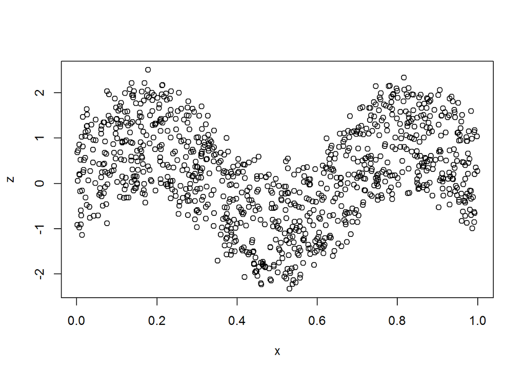

```r
z<-sin(3*pi*x)+cos(3*pi*y)+rnorm(1000, mean=0, sd=0.25)
plot(z~x)
```

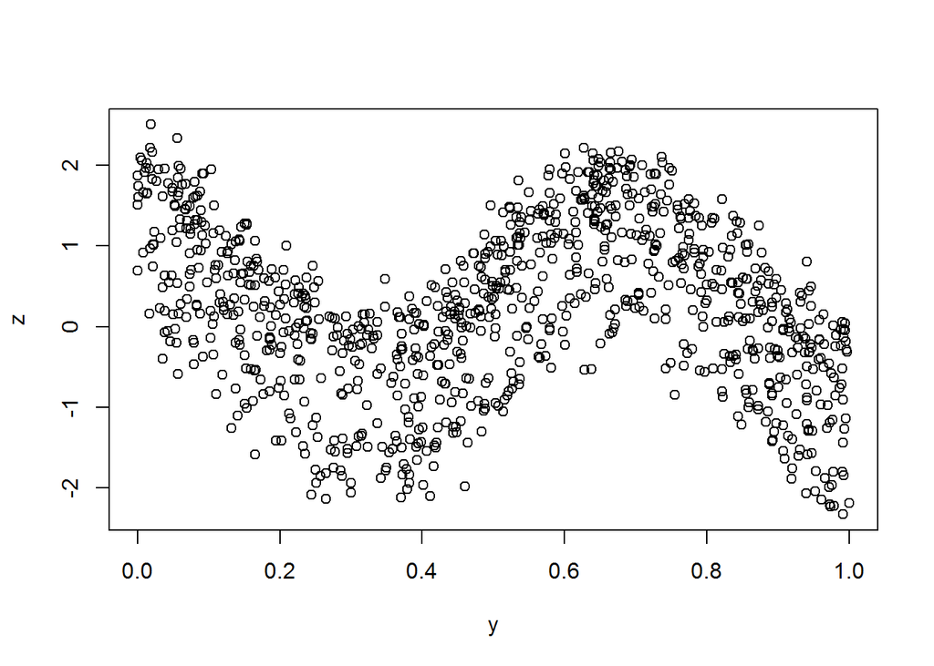

```r
plot(z~y)
```

```r
dat<-data.frame(x,y,z)
head(dat)
```

```
##           x         y          z
## 1 0.9482295 0.4363093 -0.1016586
## 2 0.1703275 0.9801482 -0.2491468
## 3 0.8830342 0.1938368  0.6104850
## 4 0.2812241 0.3948473 -0.3782473
## 5 0.3977685 0.8244907 -0.3420960
## 6 0.3933799 0.9425845 -1.2907994
```

now we estimate a neural network with one hidden layer of 4 nodes

```r
library(neuralnet)
nn<-neuralnet(z~x+y, data=dat, hidden=4, stepmax=2e05, threshold=0.02, lifesign="full")
```

```
## hidden: 4    thresh: 0.02    rep: 1/1    steps:    1000  min thresh: 0.4697060622
##                                                    2000  min thresh: 0.4389651071
##                                                    3000  min thresh: 0.2801552018
##                                                    4000  min thresh: 0.1811456491
##                                                    5000  min thresh: 0.1229516324
##                                                    6000  min thresh: 0.09468489062
##                                                    7000  min thresh: 0.06227955803
##                                                    8000  min thresh: 0.05292197668
##                                                    9000  min thresh: 0.05041584795
##                                                   10000  min thresh: 0.0416033961
##                                                   11000  min thresh: 0.04118934305
##                                                   12000  min thresh: 0.0374404093
##                                                   13000  min thresh: 0.0374404093
##                                                   14000  min thresh: 0.03479888158
##                                                   15000  min thresh: 0.03291696601
```

[output cut: 60 more lines]

```r
plot(nn)
```

now we check do our predictions of the neural network look good?

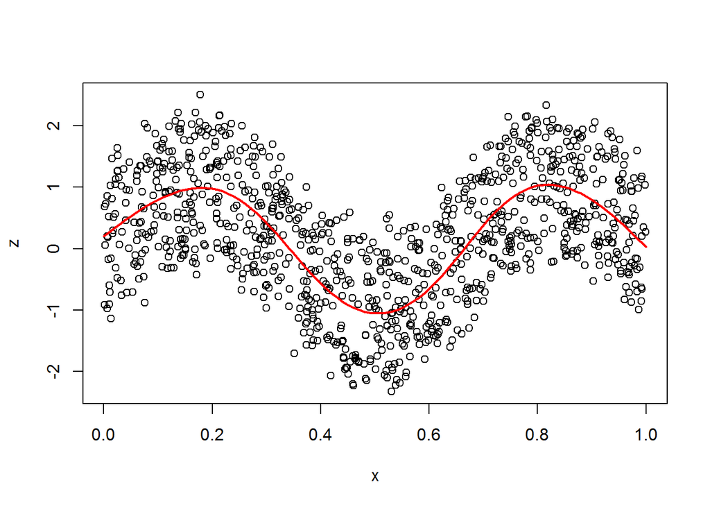

```r
x.test<-seq(from=0, to=1, by=0.01)
z.fit<-compute(nn, covariate=matrix(c(x.test, rep(0.5, length(x.test))), nrow=length(x.test), ncol=2))$net.result
plot(z~x, data=dat)
lines(z.fit~x.test, type="l", col="red", lwd=2)
```

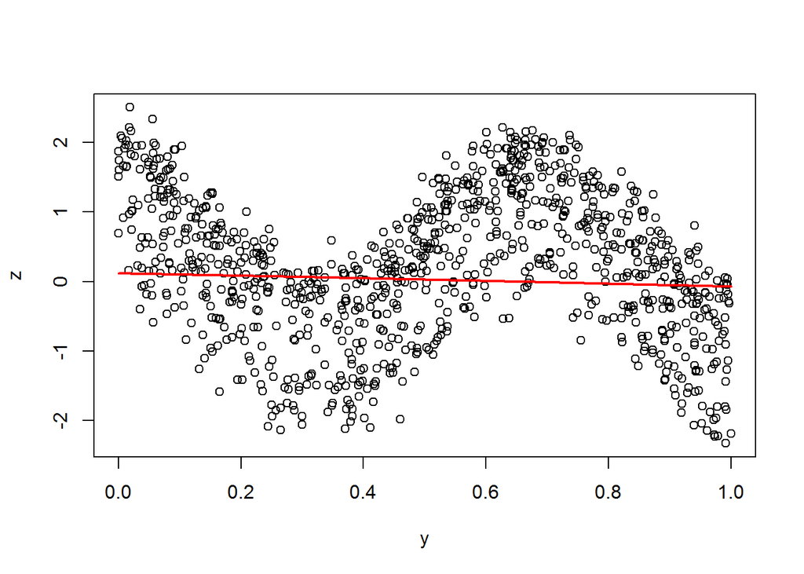

```r
y.test<-seq(from=0, to=1, by=0.01)
z.fit<-compute(nn, covariate=matrix(c(rep(1, length(y.test)), y.test), nrow=length(y.test), ncol=2))$net.result
plot(z~y, data=dat)
lines(z.fit~y.test, type="l", col="red", lwd=2)
```

….here the fitting is not very good, so, We need a more complex fitting surface.so we try more number of hidden layers or more number of hidden neurons

now Trying with eight nodes in the hidden layer.

```r
nn<-neuralnet(z~x+y, data=dat, hidden=8, stepmax=2e05, threshold=0.02, lifesign="full")
```

```
## hidden: 8    thresh: 0.02    rep: 1/1    steps:    1000  min thresh: 1.931653935
##                                                    2000  min thresh: 1.439426706
##                                                    3000  min thresh: 0.8145055061
##                                                    4000  min thresh: 0.5145979117
##                                                    5000  min thresh: 0.3933560063
##                                                    6000  min thresh: 0.3887210981
##                                                    7000  min thresh: 0.2925466501
##                                                    8000  min thresh: 0.2925466501
##                                                    9000  min thresh: 0.2436580544
##                                                   10000  min thresh: 0.2395004085
##                                                   11000  min thresh: 0.2098794002
##                                                   12000  min thresh: 0.2044901612
##                                                   13000  min thresh: 0.1933940957
##                                                   14000  min thresh: 0.1709527908
##                                                   15000  min thresh: 0.1590452306
```

[output cut: 66 more lines]

```r
plot(nn)

x.test<-seq(from=0, to=1, by=0.01)
z.fit<-compute(nn, covariate=matrix(c(x.test, rep(0.5, length(x.test))), nrow=length(x.test), ncol=2))$net.result
plot(z~x, data=dat)
lines(z.fit~x.test, type="l", col="red", lwd=2)

y.test<-seq(from=0, to=1, by=0.01)
z.fit<-compute(nn, covariate=matrix(c(rep(1, length(y.test)), y.test), nrow=length(y.test), ncol=2))$net.result
plot(z~y, data=dat)
lines(z.fit~y.test, type="l", col="red", lwd=2)
```

[output not shown]

Problem 2 :classification problem

```r
rm(list=ls())
set.seed(29124)

x<-runif(1000)
y<-runif(1000)
o<-order(y)
```

the points will lie (noisily) in one class if inside a circle centered at zero with radius (0.5)^(1/2), and in another class if outside this circle

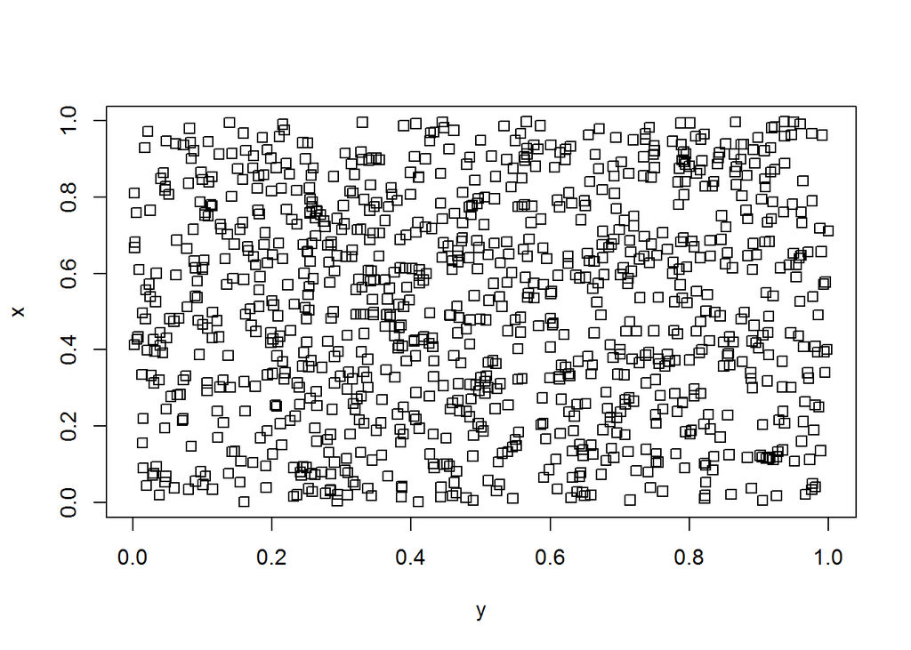

```r
z<-ifelse(x^2+y^2+runif(1000, min=-0.15, max=0.15)>0.5, 1, 0)
plot(x~y, pch=y)
```

```r
dat<-data.frame(x,y,z)
```

testing a glm (probit) model if it correctly classify these observations?

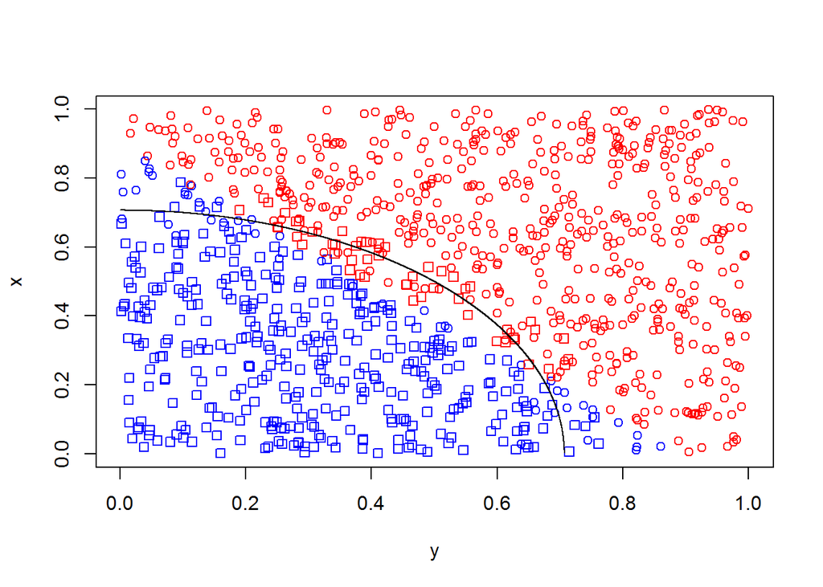

```r
glm.mod<-glm(z~x+y, family=binomial)
glm.class<-ifelse(predict(glm.mod, type="response")>0.5, "red", "blue")
plot(x~y, pch=z, col=glm.class)
y.plot<-seq(from=0, to=sqrt(0.5), by=0.0001)
lines(sqrt(0.5-y.plot^2)~y.plot)
```

…no, or at least not without some substantial modification (like polynomial terms). It draws a line through the circular boundary space.Which is very wrong.

modelling a neural network with a single layer of four hidden nodes,

```r
library(neuralnet)
nn<-neuralnet(z~x+y, data=dat, linear.output=FALSE, hidden=4, lifesign="full")
```

```
## hidden: 4    thresh: 0.01    rep: 1/1    steps:    1000  min thresh: 0.02748038646
##                                                    2000  min thresh: 0.02748038646
##                                                    3000  min thresh: 0.02748038646
##                                                    4000  min thresh: 0.02166207774
##                                                    5000  min thresh: 0.02166207774
##                                                    6000  min thresh: 0.02166207774
##                                                    7000  min thresh: 0.02166207774
##                                                    8000  min thresh: 0.02166207774
##                                                    9000  min thresh: 0.02166207774
##                                                   10000  min thresh: 0.02166207774
##                                                   11000  min thresh: 0.02166207774
##                                                   12000  min thresh: 0.02166207774
##                                                   13000  min thresh: 0.02022756245
##                                                   14000  min thresh: 0.01981199136
##                                                   15000  min thresh: 0.0195481622
```

[output cut: 25 more lines]

```r
plot(nn)
```

so we see that inside the sample data set, the neural network model classifies the dataset quite well.

```r
nn.dat<-prediction(nn)$data
```

```
## Data Error:  0;
```

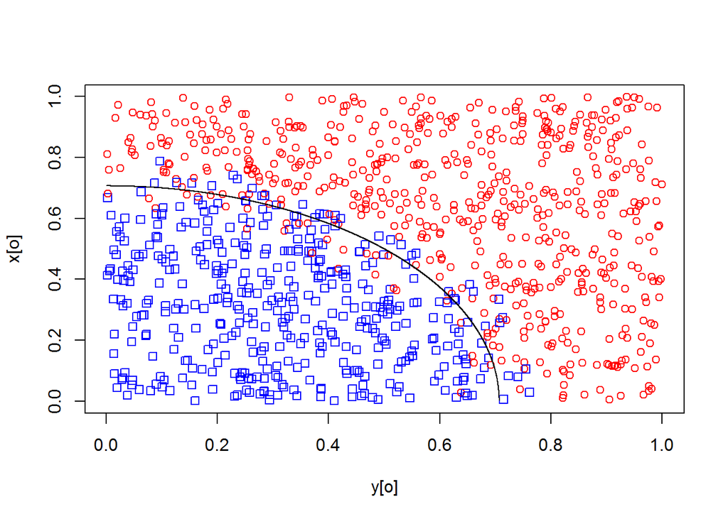

```r
nn.class<-ifelse(nn.dat[,"z"]>0.5, "red", "blue")
plot(x[o]~y[o], pch=z[o], col=nn.class)
y.plot<-seq(from=0, to=sqrt(0.5), by=0.0001)
lines(sqrt(0.5-y.plot^2)~y.plot)
```

next we check how does it do on test dataset

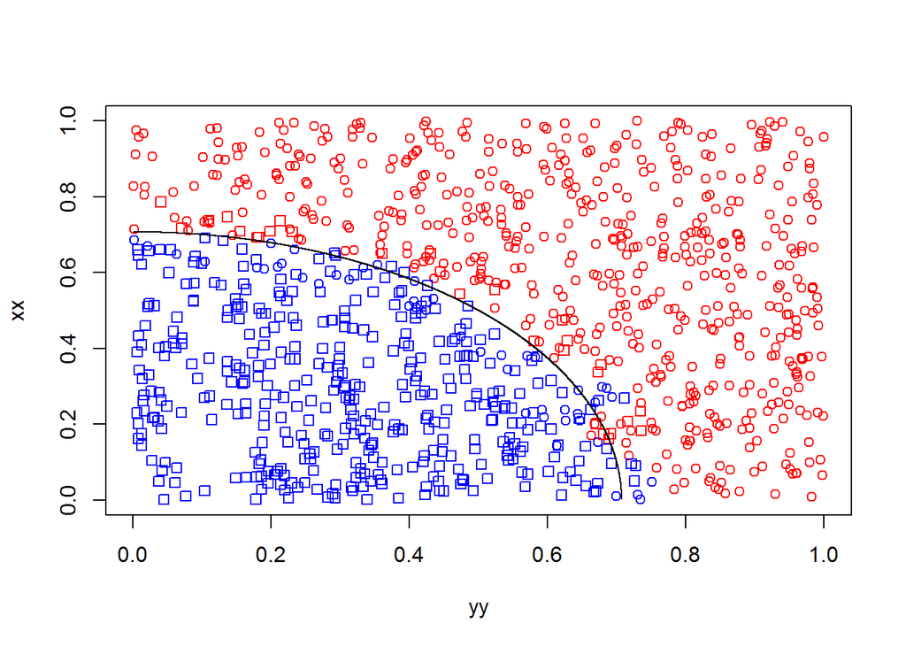

```r
xx<-runif(1000)
yy<-runif(1000)
zz<-ifelse(xx^2+yy^2+runif(1000, min=-0.15, max=0.15)>0.5, 1, 0)

nn.class.p<-ifelse(compute(nn, covariate=data.frame(x=xx, y=yy))$net.result>0.5, "red", "blue")
plot(xx~yy, pch=zz, col=nn.class.p)
y.plot<-seq(from=0, to=sqrt(0.5), by=0.0001)
lines(sqrt(0.5-y.plot^2)~y.plot)
```

its performance is much better compared to GLM. We have almost perfect separation of the classes at the limit of what is possible given noise levels.